# Make Matchups

Spot-check a handful of sites with a large enough record (> 1500 observations) that the pattern is legible: flagged points should look like genuine spectral excursions (residual cloud/shadow contamination, glint) rather than a large fraction of any one site’s record.

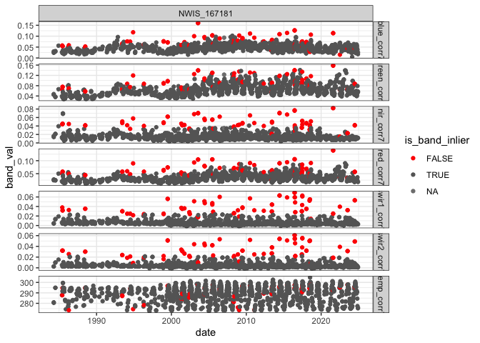

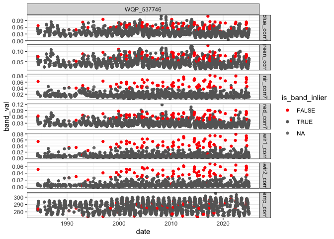

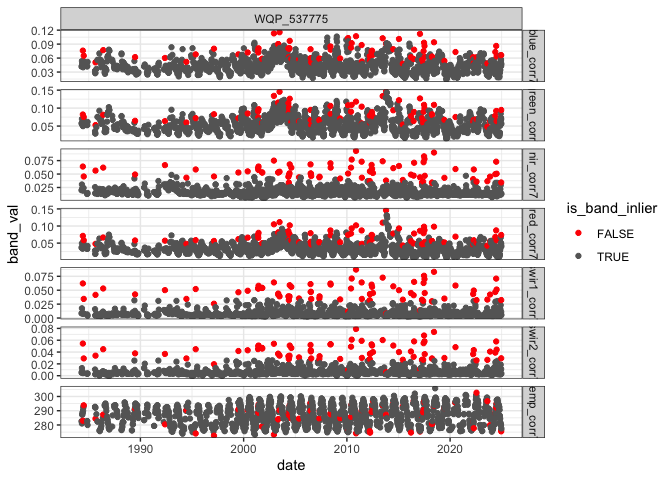

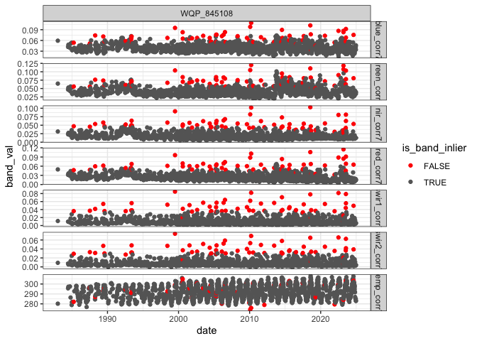

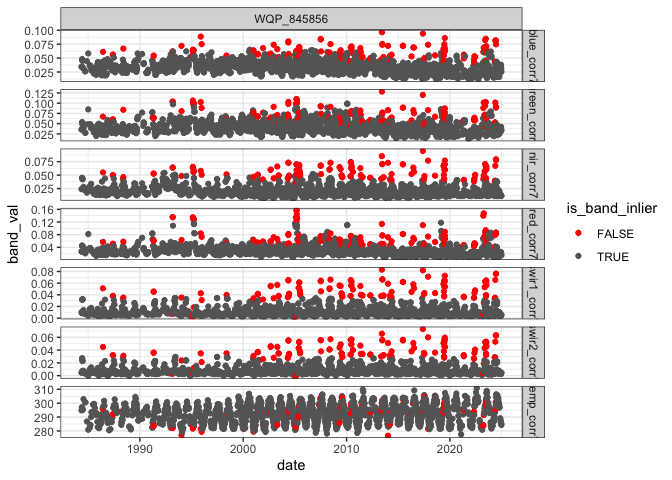

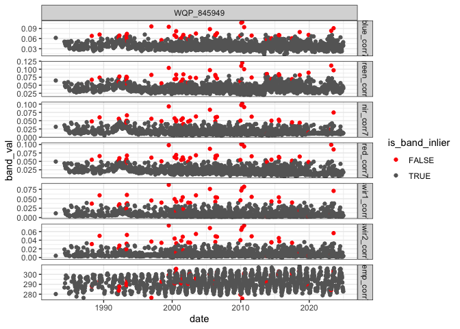

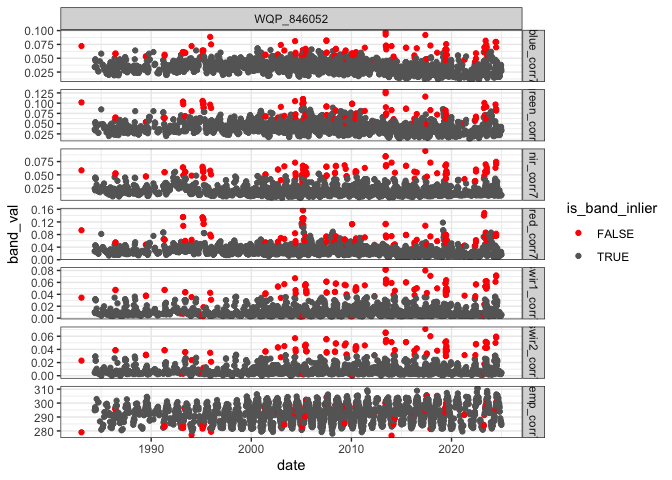

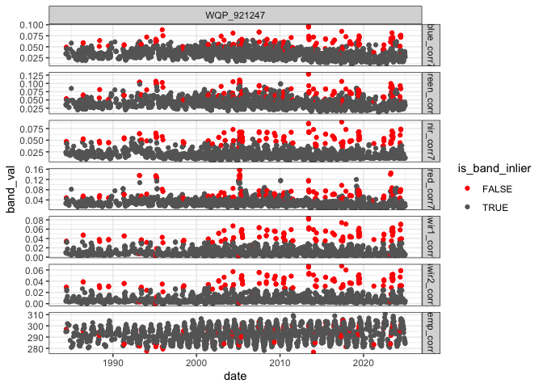

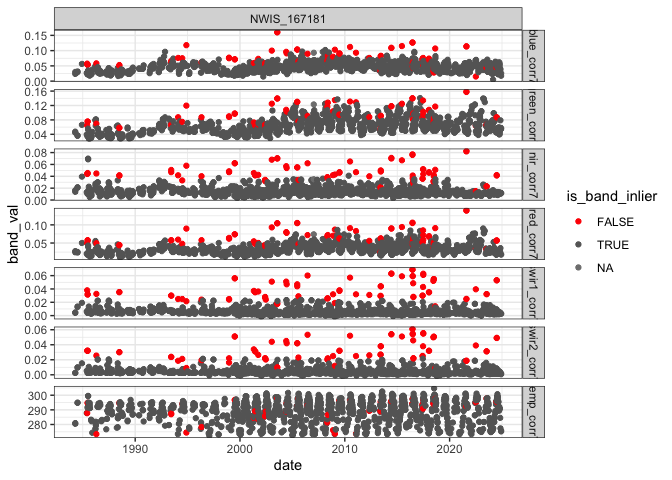

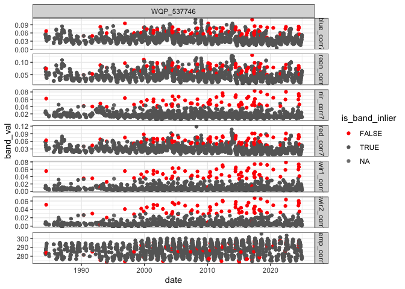

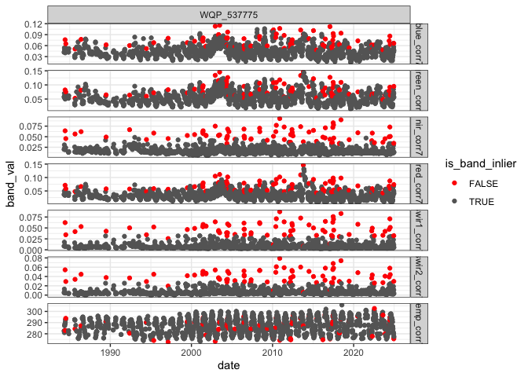

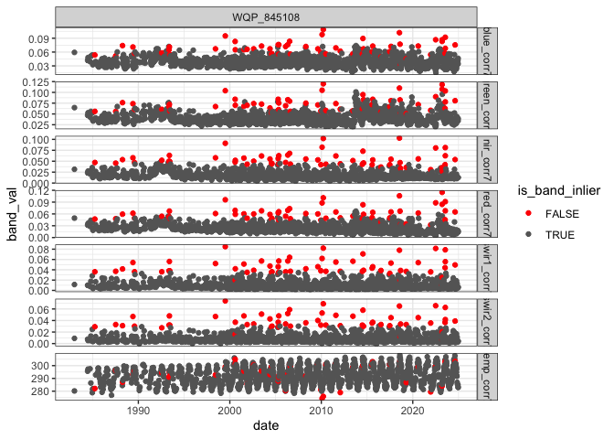

[4 more figures not shown]

```r
spotcheck_sites <- siteSR_regional_corr[, .N, by = siteSR_id][N > 1500, siteSR_id]
map(.x = spotcheck_sites,
    .f = ~ print(
      siteSR_regional_corr[siteSR_id == .x] %>%
        pivot_longer(cols = all_of(band_cols),
                     names_to = "band",
                     values_to = "band_val") %>%
        ggplot(.,
               aes(x = date, y = band_val, color = is_band_inlier)) +
        geom_point() +
        facet_grid(band ~ siteSR_id, scales = "free_y") +
        scale_color_manual(values = c(`TRUE` = "grey40", `FALSE` = "red")) +
        theme_bw()
    )
)
```

Some of these look like they might belong to the same waterbody or are sites that are very close to one another, even after the de-duplication step.

Check whether flagging concentrates at reflectance extremes rather than spreading evenly across the range of each band - the same “does this look like real signal being cut, or generic scene noise” question asked of the SDD-only filter above, just against the band values themselves since no SDD/harmonized_value exists on this pre-match data. Even spreading here is consistent with catching genuine spectral noise (cloud/shadow edges, glint); concentration at one band’s extremes would suggest the filter is instead cutting real, legitimately bright or dark water.

`is_band_inlier` is `NA` for any site the RANSAC fit above never resolved (too few points, no degenerate-date-free draw, etc.) - a plain `sum(!is_band_inlier)` without `na.rm` would turn `n_flagged` (and thus `frac_flagged`) `NA` for any bin containing even one such site, silently dropping that bin’s bar. Tracking flagged/not-flagged/NA as their own counts keeps NA visible as its own category instead of erasing bins.

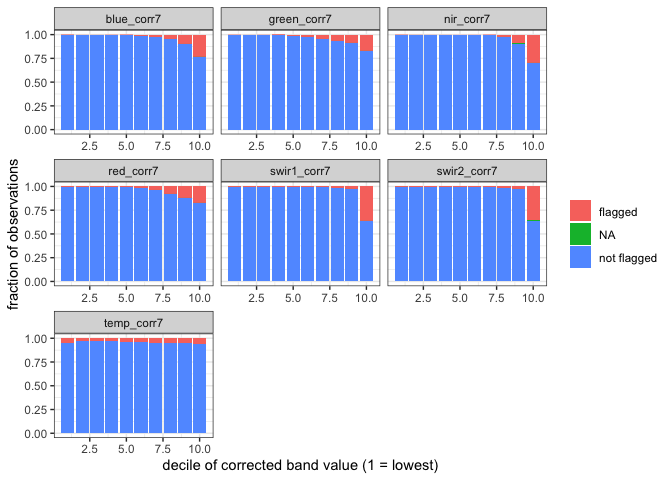

```r
band_tail_check <- rbindlist(lapply(band_cols, function(b) {
  siteSR_regional_corr[, .(band = b, bin = ntile(get(b), 10), is_band_inlier)]
}))[, .(n = .N,
        n_flagged = sum(is_band_inlier == FALSE, na.rm = TRUE),
        n_unflagged = sum(is_band_inlier == TRUE, na.rm = TRUE),
        n_na = sum(is.na(is_band_inlier))), by = .(band, bin)
][, `:=`(frac_flagged = n_flagged / n,
         frac_unflagged = n_unflagged / n,
         frac_na = n_na / n)][order(band, bin)]

print(
  band_tail_check %>%
    pivot_longer(cols = c(frac_flagged, frac_unflagged, frac_na),
                 names_to = "status", values_to = "frac") %>%
    mutate(status = recode(status,
                           frac_flagged = "flagged",
                           frac_unflagged = "not flagged",
                           frac_na = "NA")) %>%
    ggplot(aes(x = bin, y = frac, fill = status)) +
    geom_col() +
    facet_wrap(~ band, scales = "free_x") +
    labs(x = "decile of corrected band value (1 = lowest)",
         y = "fraction of observations",
         fill = NULL) +
    theme_bw()
)
```

This does skew to flagging greater outliers at higher values, but that is probably real. We can further look into that by looking at sites where there are a lot of data being flagged in the 90th percentile.

Spot-check sites with a large enough record (> 1000 observations) that the pattern is legible, restricted to sites with at least one point in that band’s decile 10 (i.e. at/above the band’s global 90th percentile) - a closer look at the sites/points actually behind the decile-10 concentration surfaced above, to see whether those points look like isolated spectral noise or a recurring signal (e.g. seasonal bloom) the filter is cutting.

```r
band_p90 <- setNames(
  vapply(band_cols, function(b) {
    quantile(siteSR_regional_corr[[b]], 0.9, na.rm = TRUE)
  }, numeric(1)),
  band_cols
)
band_p90_df <- data.table(band = band_cols, p90 = band_p90)

siteSR_band_long <- rbindlist(lapply(band_cols, function(b) {
  siteSR_regional_corr[, .(siteSR_id, date, band = b, band_val = get(b),
                           is_band_inlier)]
}))

large_sites <- siteSR_regional_corr[, .N, by = siteSR_id][N > 1000, siteSR_id]
decile10_sites_all <- siteSR_band_long[
  siteSR_id %in% large_sites & band_val >= band_p90[band], unique(siteSR_id)
]

# this condition flags the vast majority of large sites (a decile-10 hit in
# any of 7 bands is a low bar), so plotting all of them stops being a spot
# check - sample a fixed, reproducible subset instead
set.seed(43)
decile10_spotcheck_n <- 25
decile10_sites <- if (length(decile10_sites_all) > decile10_spotcheck_n) {
  sample(decile10_sites_all, decile10_spotcheck_n)
} else {
  decile10_sites_all
}
```

One figure per site, rather than one huge multi-site `facet_grid`, so each site’s timeseries is actually readable. 286 sites meet the decile10 criterion above; we spot-check a random sample of 25 of them here rather than rendering all of them.

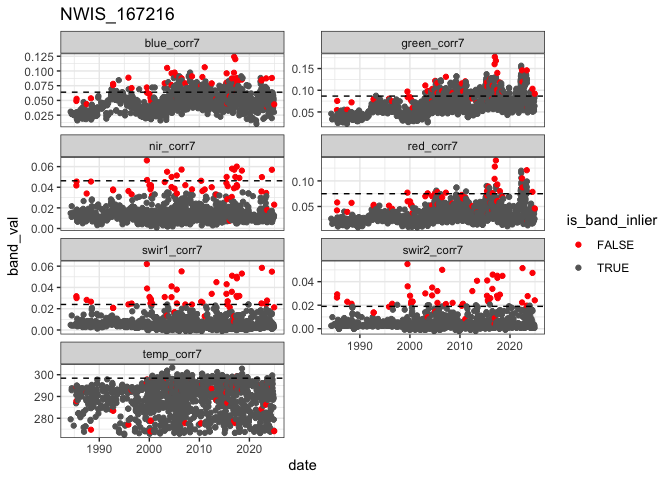

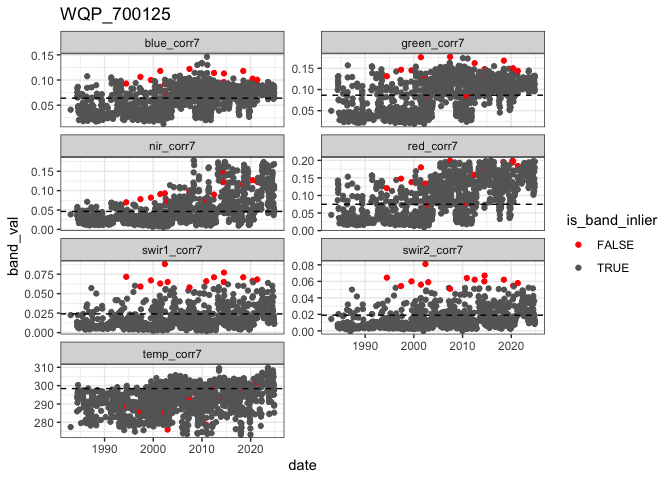

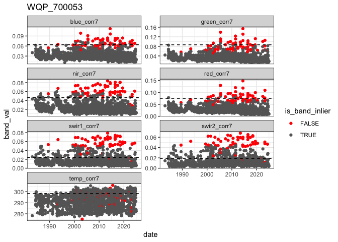

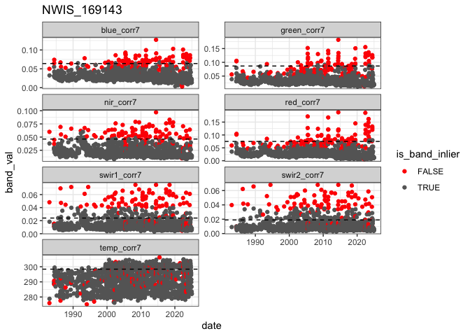

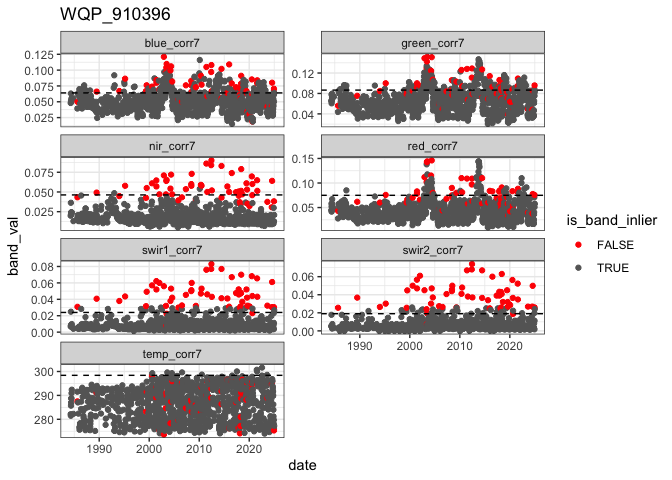

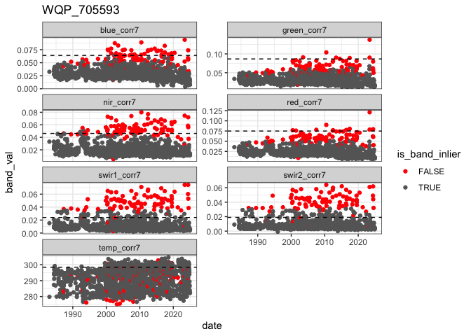

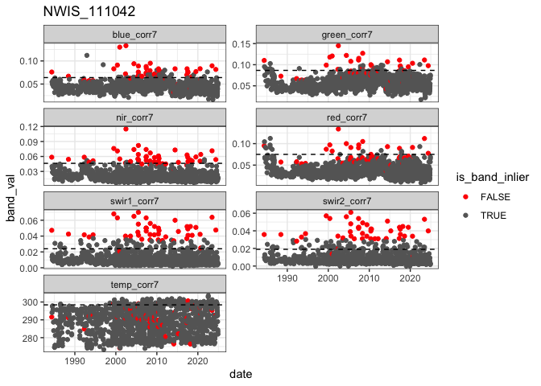

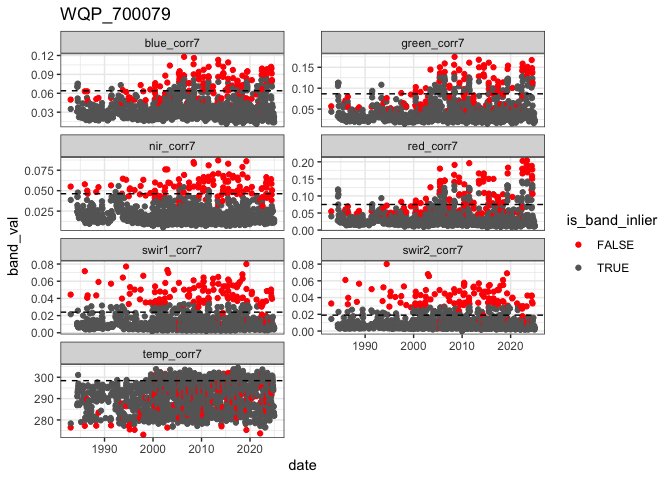

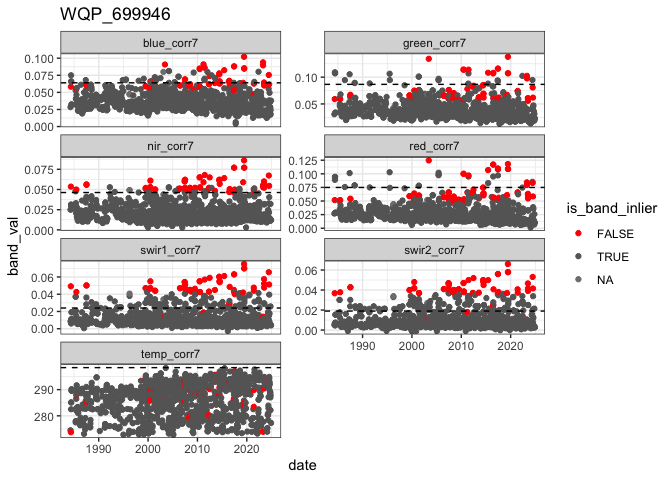

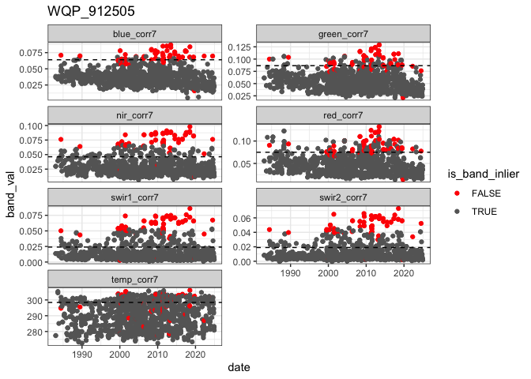

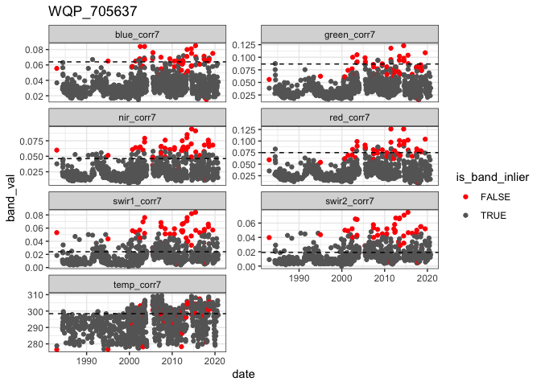

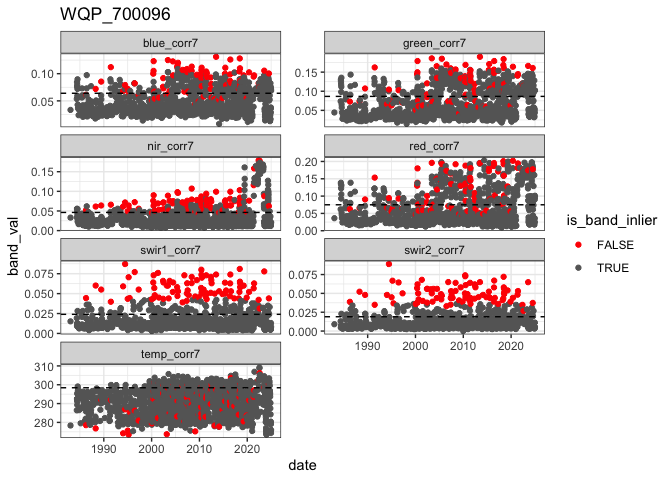

[13 more figures not shown]

```r
walk(decile10_sites, function(site) {
  print(
    siteSR_band_long[siteSR_id == site] %>%
      ggplot(aes(x = date, y = band_val, color = is_band_inlier)) +
      geom_point() +
      geom_hline(data = band_p90_df, aes(yintercept = p90),
                 linetype = "dashed") +
      facet_wrap(~ band, scales = "free_y", ncol = 2) +
      scale_color_manual(values = c(`TRUE` = "grey40", `FALSE` = "red")) +
      labs(title = site) +
      theme_bw()
  )
})
```

Can still see some related sites in here.

```r
rm(siteSR_regional_corr, band_cols,
   high_flag_sr_sites, spotcheck_sites,
   band_tail_check, band_p90, band_p90_df,
   siteSR_band_long, large_sites,
   decile10_sites, decile10_sites_all, decile10_spotcheck_n)
gc()
```

```
##            used  (Mb) gc trigger   (Mb) limit (Mb)  max used   (Mb)
## Ncells  5244071 280.1   11401355  608.9         NA  11401355  608.9
## Vcells 38372932 292.8  265251387 2023.8      65536 278458572 2124.5
```

## Make matches with the filtered data

Use the regionally band-filtered siteSR data (rather than the full nationwide `unified_data`) as the input to matching, so a site flagged above simply isn’t a match candidate.

```r
# Define paths to downloaded and stacked data
sr_sites <- siteSR[grepl("collated_WQP_NWIS_sites", siteSR)]
out_file <- file.path(aquamatch_dir, "sdd_regional_siteSR_matchups_5d.parquet")

if (file.exists(out_file)) {
  sdd_match <- read_parquet(out_file)
} else {
  # Work around a duckdb bug where it fails to create its temp directory
  # because the parent "duckdb" folder under tempdir() doesn't exist yet
  dir.create(file.path(tempdir(), "duckdb"), recursive = TRUE, showWarnings = FALSE)

  # Run the matchups with a 5-day window
  match_siteSR_to_WQP(
    wqp_path = sdd_filtered,
    siteSR_path = siteSR_regional_filtered,
    site_list_path = sr_sites,
    save_location = out_file,
    time_window = "5 days"
  )

  # Read file
  sdd_match <- read_parquet(out_file)
}
```

Let’s limit to Lake data for our purposes and remove the Great Lakes - this is a back up to the site filters above

```r
lake_sdd <- sdd_match %>%
  filter(
    # select for lake/reservoir only
    grepl("Lake|Reservoir", MonitoringLocationTypeName),
    # remove the great lakes for this matching process
    !grepl("Great", MonitoringLocationTypeName)
  )

# check to see if these are the same
nrow(lake_sdd) == nrow(sdd_match)
```

```
## [1] TRUE
```

## Summary Figures

```r
sites <- read_csv(sr_sites)
sites_w_matches <- sites %>%
  filter(siteSR_id %in% unique(sdd_match$siteSR_id)) %>%
  st_as_sf(coords = c("WGS84_Longitude", "WGS84_Latitude"), crs = "EPSG:4326")

# let's drop the ones that are outside the CONUS for the purposes of this
conus <- suppressMessages(states(progress_bar = FALSE)) %>%
  filter(!grepl("AK|AS|MP|VI|HI|PR|GU", STUSPS))

lake_locs_CONUS <- sites_w_matches %>%
  st_transform(., st_crs(conus)) %>%
  .[conus,] %>%
  st_transform(., st_crs(sites_w_matches))
```

And plot

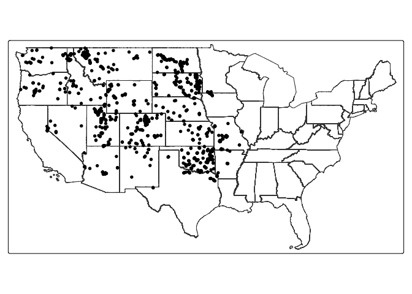

```r
tm_shape(conus) +
  tm_borders() +
  tm_shape(lake_locs_CONUS) +
  tm_dots()
```

Make some summary tables

```r
# summarize by number of matches per site
five_day_summary <- sdd_match %>%
  summarize(n = n(),
            .by = siteSR_id)

# add in spatial data
lake_locs_with_matches <- lake_locs_CONUS %>%
  filter(siteSR_id %in% unique(sdd_match$siteSR_id)) %>%
  left_join(., five_day_summary)
```

Plot locations colored by number of matches

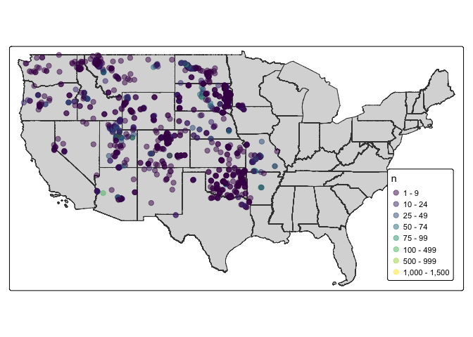

```r
# plot all missions
tm_shape(conus) +
  tm_polygons() +
  tm_shape(lake_locs_with_matches, bbox = conus) +
  tm_dots("n",
          fill.scale = tm_scale(breaks = c(1, 10, 25, 50, 75, 100,
                                           500, 1000, 1500),
                                values = "viridis"),
          size = 0.5,
          fill_alpha = 0.5) +
  tm_layout(legend.position = tm_pos_in("right", "bottom"),
            legend.bg.color = "white",
            legend.frame = TRUE)
```

And also by number of matches per mission

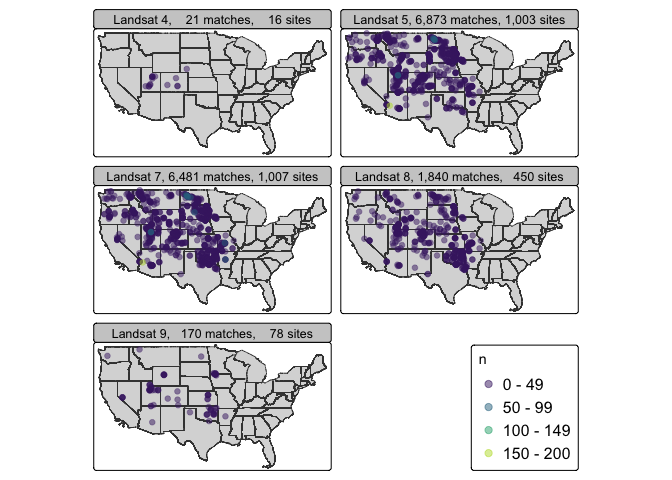

```r
# and per site per mission
five_day_summary_sensor <- sdd_match %>%
  summarize(n = n(),
            .by = c(siteSR_id, mission))

# add spatial data and label info
lake_locs_by_mission <- lake_locs_CONUS %>%
  select(siteSR_id, geometry) %>%
  right_join(five_day_summary_sensor, by = "siteSR_id") %>%
  mutate(mission = factor(mission,
                          levels = c("LT04", "LT05", "LE07", "LC08", "LC09"),
                          labels = c("Landsat 4", "Landsat 5", "Landsat 7", "Landsat 8", "Landsat 9")))%>%
  arrange(n)

# Compute totals per mission before faceting
mission_stats <- lake_locs_by_mission %>%
  st_drop_geometry() %>%
  summarize(total_matches = sum(n),
            total_sites = n_distinct(siteSR_id),
            .by = mission)

# and prep for viz
lake_locs_by_mission <- lake_locs_by_mission %>%
  left_join(mission_stats, by = "mission") %>%
  mutate(mission_label = paste0(mission, ", ",
                                format(total_matches, big.mark = ","), " matches, ",
                                format(total_sites, big.mark = ","), " sites")) %>%
  arrange(n)

# plot!
tm_shape(conus) +
  tm_polygons() +
  tm_shape(lake_locs_by_mission, bbox = conus) +
  tm_dots("n",
          fill.scale = tm_scale(values = "viridis"),
          fill.legend = tm_legend(position = tm_pos_on_top(pos.h = "right", pos.v = "bottom"),
                                  bg.color = "white",
                                  frame = TRUE, text.size = 1),
          size = 0.5,
          fill_alpha = 0.5) +
  tm_facets_wrap(by = "mission_label", ncol = 2, nrow = 3)
```